# Data Visualization and Mass Incarceration

AAAS 345 Final Project

Ben Wallace https://github.com/ben-j-wallace/  
November 22, 2021

## Introduction

> The best available methods of sociological research are at present so liable to inaccuracies that the careful student discloses the results of individual research with diffidence; he knows that they are liable to error from the seemingly ineradicable faults of the statistical method, to even greater error from the methods of general observation, and, above all, he must ever tremble lest some personal bias, some moral conviction or some unconscious trend of thought due to previous training, has to a degree distorted the picture in his view.

Tucked in the right corner of a room at the 1900 Paris Exposition, W.E.B. Du Bois’s “American Negro Exhibit” attracted thousands of visitors with its walls of photographs and boldly designed charts. The sociologist and his team of students built a story of Black progress more than forty years after emancipation after combing through dozens of images of ministers, students, cotton mill workers, and others (Rusert and Battle-Baptiste 2018).

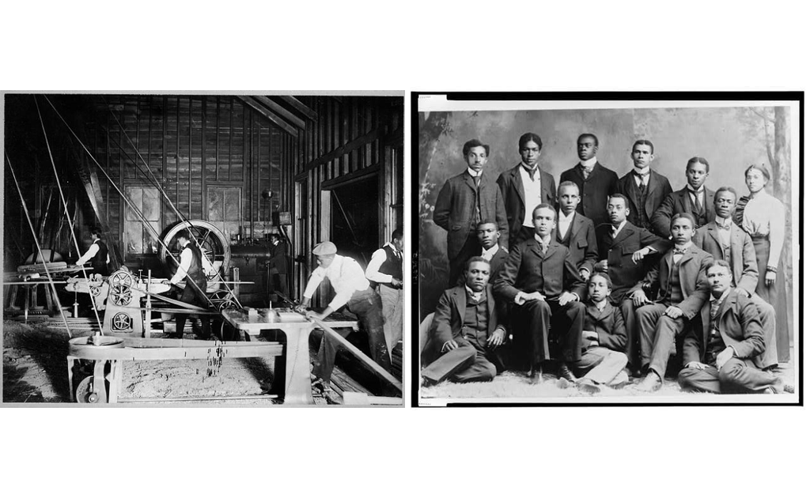

Figure 1: Photographs from American Negro Exhibit. Library of Congress. Digital ID: https://www.loc.gov/pictures/item/00651765/

[figure not shown]

Figure 2: Charts from American Negro Exhibit. Library of Congress. Digital ID: https://www.loc.gov/pictures/item/2005676812/

Du Bois’s choices to exhibit Black advancement stood in contrast to his other work, which emphasized the extreme inequities and racial discrimination plaguing the country at the turn of the century (Du Bois 1899). Like white racial scholars, he also drew from Census, crime, and social survey data to build narratives about the so-called “race problem.” However, while well-versed in the language of statistics and methodology, Du Bois understood the limits of numbers in representing and used this knowledge to confront the harmful myths of Black criminality, immorality, and biological inferiority. He challenged Frederick Hoffman, president of the American Statistics Association, on the methodological errors and prejudiced judgments that he concealed through the veil of scientific authority. Ultimately, Du Bois and other Black leaders interrogated how numbers themselves can play a role in dismantling such oppressive notions.

In the century since the “American Negro Exhibit,” the practice of data visualization has dramatically evolved in tandem with developments in visual criminology, social statistics, and the statistical knowledge state. This paper addresses the prospects, limitations, and implications of using data visualization in representing the bodies and discources surrounding the carceral system. Specifically, I ask: how can these portraits intervene in representations of those the system entangles, a system which so frequently neglects humanity to those it holds captive? I respond to this question by discussing the necessary ways in which data visualizations can represent scale, social context, and alternatives to policing and prisons to visually denaturalize the carceral imagination in our daily lives.

## Data visualizations, what are they?

One of the most defining features of statistical data is that they are both empirically and practically limited to what is countable. These two bounds limit the types of questions for which a data visualization is a suitable answer. One must only examine the intricacies of prison maintenance, for example, to understand the restrictions of data visualizations. The prison-industrial complex is an “array of relationships linking corporations, government, correctional communities, … the media” and other institutions (Davis 2011a). Scholars like Angela Davis “[hesitate] to make unmediated… use of such statistical evidence because it can discourage the very critical thinking that ought to be elicited by an understanding of the prison industrial complex” (Davis 2011b).

Statisticians, data scientists, and data visualizationists must also contend with the invisible biases of historical data, how they reproduce “common sense” ideas about Black, Indigenous, and other marginalized communities, and disguise these conclusions as self-evident knowledge (Muhammad 2019). Because of these shortcomings, researchers should interrogate the reliability of institutional and historical data. While these issues can be particularly rectified through the combination of several data sources, it is more important that researchers consider these data within their respective contexts. What can they realistically measure, what human and systematic biases do they contain, and how are these statistics relevant to one’s questions or goals?

Davis, Angela Y. 2011a. “The Prison-Industrial Complex.” In *Are Prisons Obsolete?*, 84. Seven Stories Press.

———. 2011b. “The Prison-Industrial Complex.” In *Are Prisons Obsolete?*, 92. Seven Stories Press.

Du Bois, William Edward Burghardt. 1899. “Chapter 18: A Final Word.” In *The Philadelphia Negro: A Social Study*, 401–12. Philadelphia, PA: Schocken Books.

Hepworth, Katherine, and Christopher Church. 2018. “Racism in the Machine: Visualization Ethics in Digital Humanities Projects.” *Digital Humanities Quarterly* 12 (4).

Muhammad, Khalil Gibran. 2019. “Saving the Nation: The Racial Data Revolution and the Negro Problem.” In *The Condemnation of Blackness: Race, Crime, and the Making of Modern Urban America, with a New Preface*. Harvard University Press.

Rusert, Britt, and Whitney Battle-Baptiste. 2018. *W. E. B. Du Bois’s Data Portraits : Visualizing Black America*. New York, NY, UNITED STATES: Princeton Architectural Press.